# HCC Session - LL1

# Viz 2

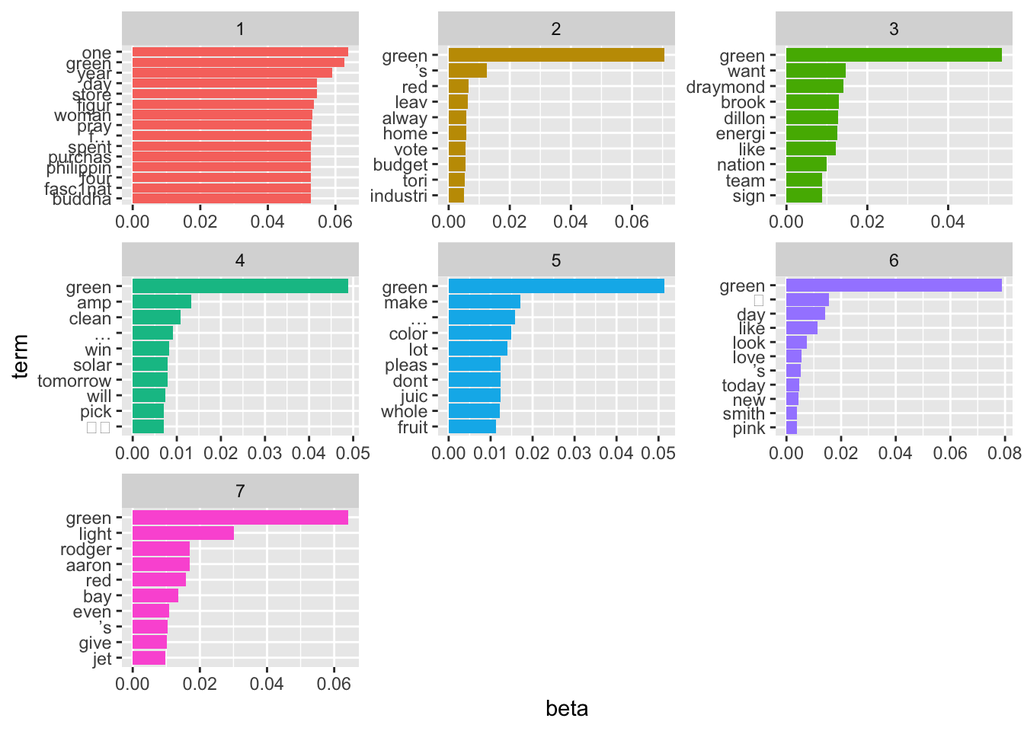

```r
green_top_terms1 %>%
  mutate(term = reorder_within(term, beta, topic)) %>%
  ggplot(aes(beta, term, fill = factor(topic))) +
  geom_col(show.legend = FALSE) +
  facet_wrap(~ topic, scales = "free") +
  scale_y_reordered()
```

Above we have our topic model and the top terms associated with each. We can see that topic 3 has to do with basketball, topic 5 may be about healthy eating, and topic 4 seems to be about clean energy.

## Word Cloud

Now let’s go back to the Biden tweets and make a word cloud. What’s a word cloud? Read about it here: https://towardsdatascience.com/create-a-word-cloud-with-r-bde3e7422e8a

```r
words_data <- biden_tweets %>%
  select(text)%>%
  unnest_tokens(word, text)

#let's get rid of some words associated with links and things that might cause errors

words_data <- words_data %>%
  filter(!word %in% c('https', 't.co', 'he\'s', 'i\'m', 'it\'s'))

#let's get rid of stopwords

words_data2 <- words_data %>%
  anti_join(stop_words) %>%
  count(word, sort = TRUE)
```

## Viz 3

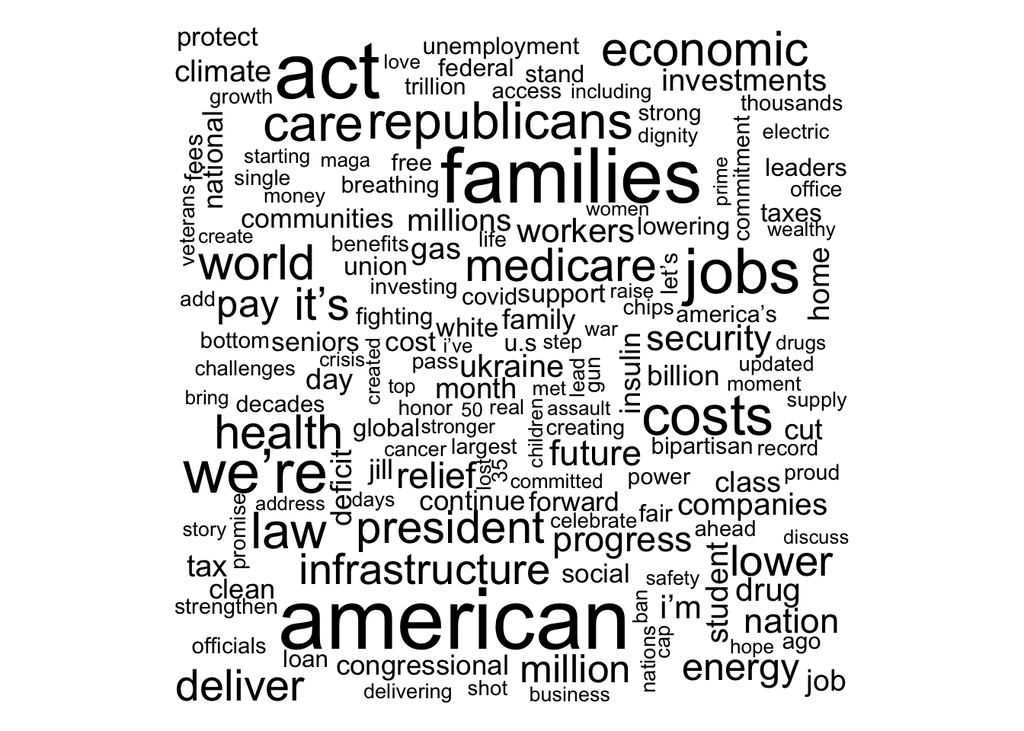

```r
#Basic word cloud

wordcloud(words_data2$word,words_data2$n, max.words = 200)
```

## Viz 4

Now let’s make a word cloud from those tweets but highlight which words are positive and which are negative

```r
words_data2 %>%
  inner_join(get_sentiments("bing")) %>%
  count(sentiment, sort = TRUE)
```

```
## # A tibble: 2 × 2
##   sentiment     n
##   <chr>     <int>
## 1 negative    334
## 2 positive    328
```

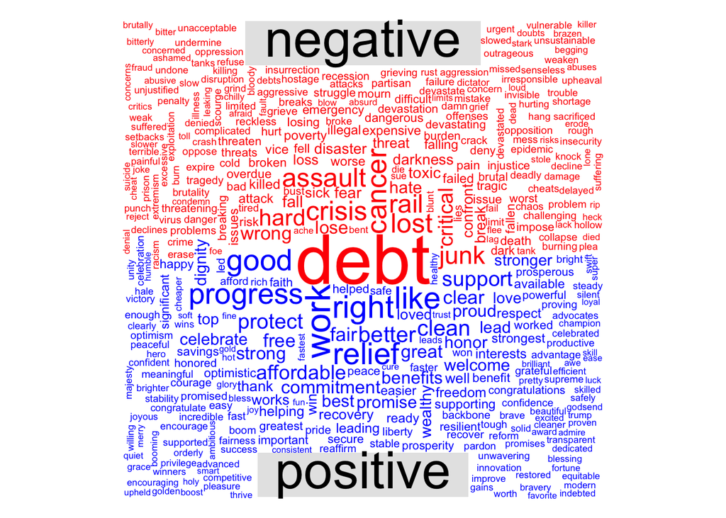

```r
profanity_list <- unique(tolower(lexicon::profanity_alvarez))

words_data %>%
  filter(!word %in% c('https', 't.co', 'he\'s', 'i\'m', 'it\'s', profanity_list)) %>%
  inner_join(get_sentiments("bing")) %>%
  count(word, sentiment, sort = TRUE) %>%
  acast(word ~ sentiment, value.var = "n", fill = 0) %>%
  comparison.cloud(colors = c("red", "blue"),
                   max.words = Inf)
```

## Sentiment Analysis

Now we are going to see how many of President Biden’s tweets can be classified as positive, neutral, and negative. sentimentr is the main package in use here

```r
tweet_sentences_data <- sentiment(get_sentences(biden_tweets$text)) %>%
  group_by(element_id) %>%
  summarize(meanSentiment = mean(sentiment))

#objects representing the number of positive, neutral, and negative tweets from President Biden

negative_t <- sum(tweet_sentences_data$meanSentiment < 0)
neutral_t <- sum(tweet_sentences_data$meanSentiment == 0)
positive_t <- sum(tweet_sentences_data$meanSentiment > 0)

#creating vectors for a dataframe

type_tweet <- c("Negative", "Neutral", "Postive")
values <- c(negative_t, neutral_t, positive_t)

df_sentiment <- data.frame(type_tweet, values)
```

## Viz 5

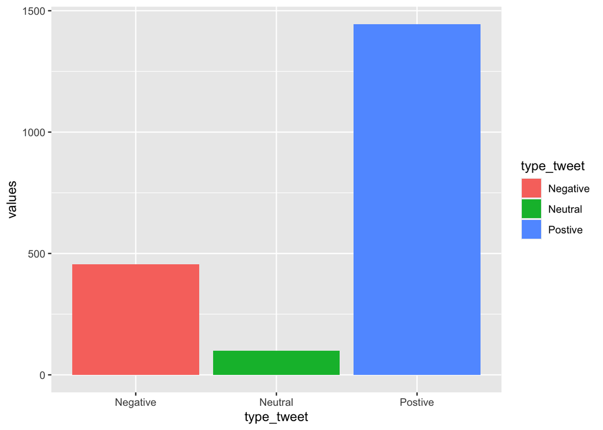

```r
p<-ggplot(data=df_sentiment, aes(x=type_tweet, y=values, fill=type_tweet)) +
  geom_bar(stat="identity")
p
```

That’s it for today!!